# **Progress Report- Group Assignment**

Elikplim Aku Setordjie, Sayesha Khanna, Abhinob Baruah and Berke Hazel Petek

21/12/2021

#### **ARTICLE AND DATA CHOSEN**

[Biocontrol of invasive pheretimoid earthworms using *Beauveria bassiana*](https://peerj.com/articles/11101/#intro)

[Data](https://dfzljdn9uc3pi.cloudfront.net/2021/11101/1/Raw_data_.xlsx)

#### **AIM OF EXPERIMENT**

To test the efficacy of *“Beauveria bassiana”* as a biocontrol agent on pheritimoid earthworms.

#### **HYPOTHESIS**

H0 : There is no significant difference between earthworms treated with *B.bassiana* and earthworms that were not treated with it.

HA : There is a significant difference between earthworms treated with *B.bassiana* and earthworms that were not treated with it.

#### **VARIABLES**

Dependent variables: Mortality, Survival

Independent variables: Treatments, Time

#### **TREATMENTS**

C1:Water

C2:Millet 15 grams

C3:Millet 25 grams

B. bassiana 108 conidia/mL

Mycoticized millet 15 g

Mycoticized millet 25 g

BotaniGard®

Some treatments were not replicated in all assays.

#### **STEPS TO TAKE TO COMPLETE THE ASSIGNMENT**

STEP 1: Repeat analysis done in paper.

STEP 2: Re analyse the data using the most appropriate analysis in your opinion.

STEP 3: Analyse data taking time into consideration.

STEP 4: Improve upon the graphics of the paper.

# **STEP 1**

## **ASSAY 1**

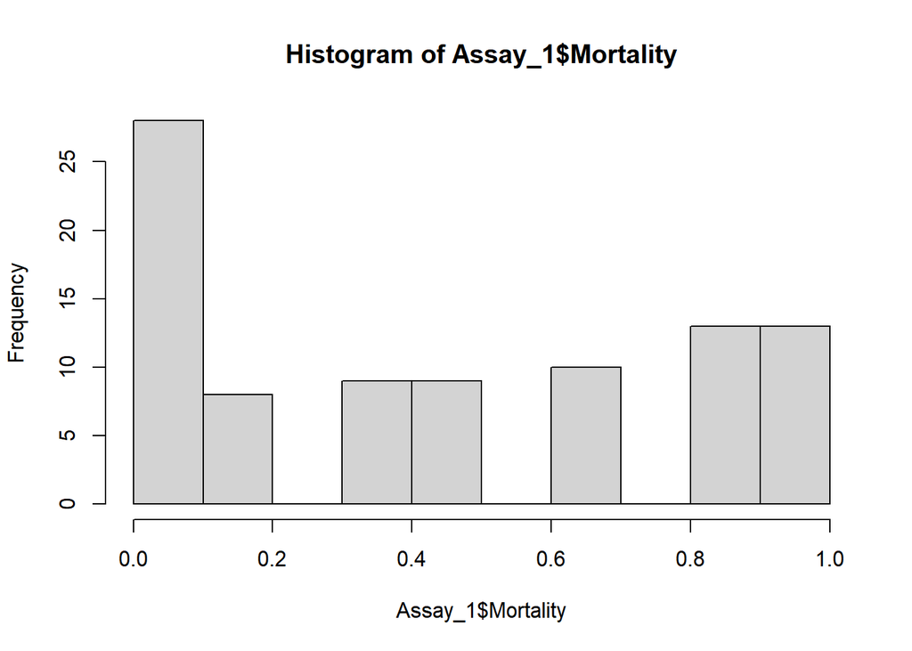

```
##
##  One-sample Kolmogorov-Smirnov test
##
## data:  Assay_1$TMortality
## D = 0.5, p-value < 2.2e-16
## alternative hypothesis: two-sided
```

```
##
##  One-sample Kolmogorov-Smirnov test
##
## data:  Anova.Assay1M$residuals
## D = 0.29879, p-value = 2.099e-07
## alternative hypothesis: two-sided
```

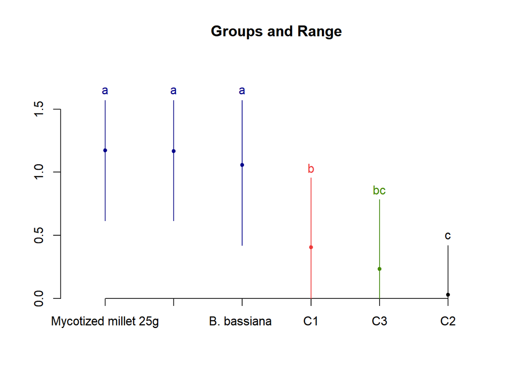

**Figure 2**: Effect of different treatments on Pheritimoid earthworm mortality. Letters indicates Tukeys HSD posthoc comparisons. Same letter indicates non-significant differences.

#Despite transforming the mortality data the article reported graphics of the untransformed data

```
##                  group       mean         se
## 1         B. bassiana  0.72222222 0.05555556
## 2                   C1 0.22222222 0.05555556
## 3                   C2 0.01111111 0.01111111
## 4                   C3 0.12222222 0.04444444
## 5 Mycotized millet 15g 0.77777778 0.05555556
## 6 Mycotized millet 25g 0.76666667 0.06465210
```

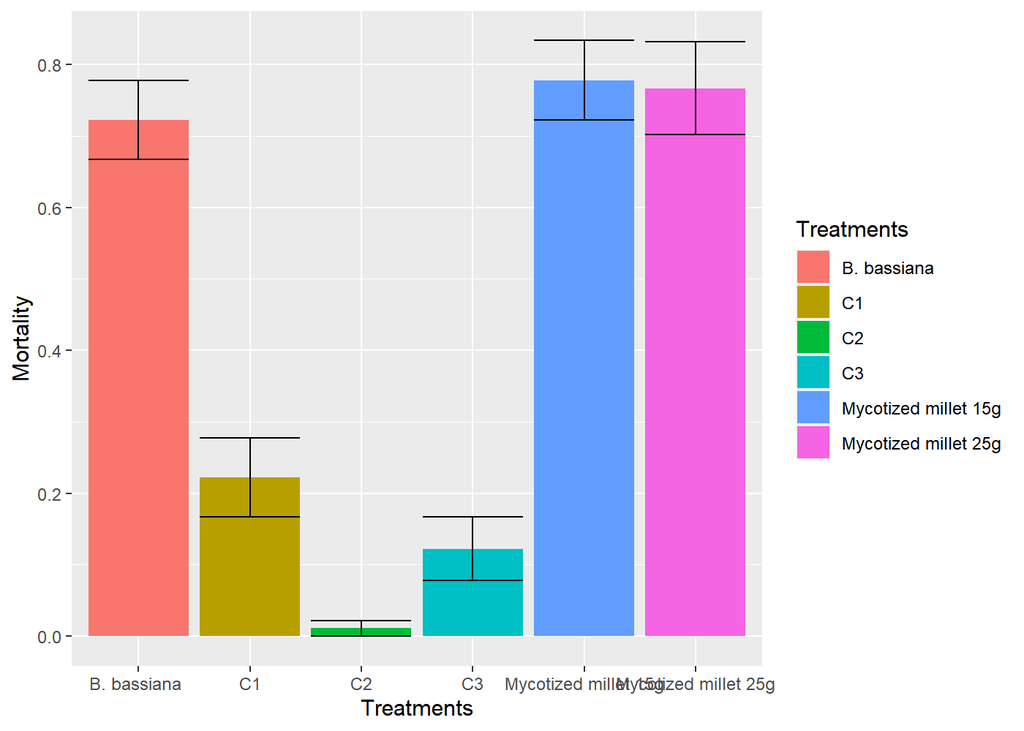

**Figure 3**:Mortality of the various treatments in Assay 1 (+/- SE)

## **ASSAY 2**

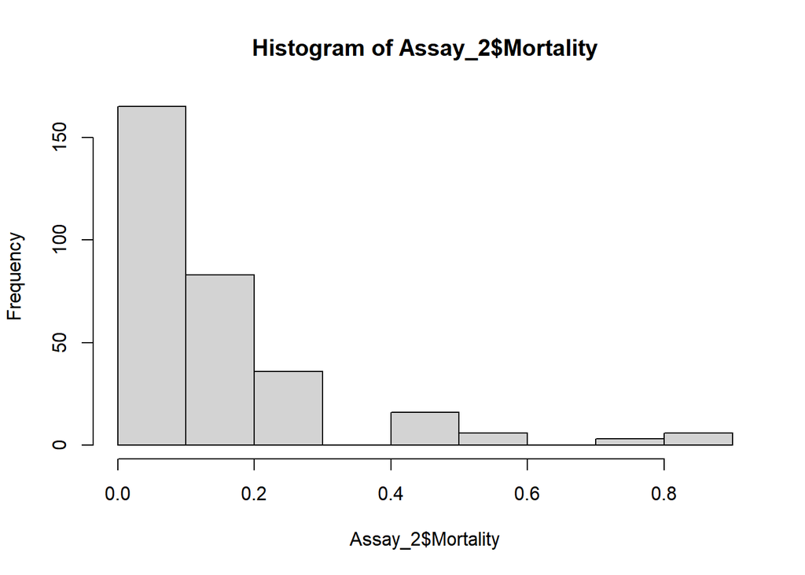

```
##
##  One-sample Kolmogorov-Smirnov test
##
## data:  Assay_2$TMortality
## D = 0.5, p-value < 2.2e-16
## alternative hypothesis: two-sided
```

```
##
##  One-sample Kolmogorov-Smirnov test
##
## data:  Anova.Assay2M$residuals
## D = 0.36492, p-value < 2.2e-16
## alternative hypothesis: two-sided
```

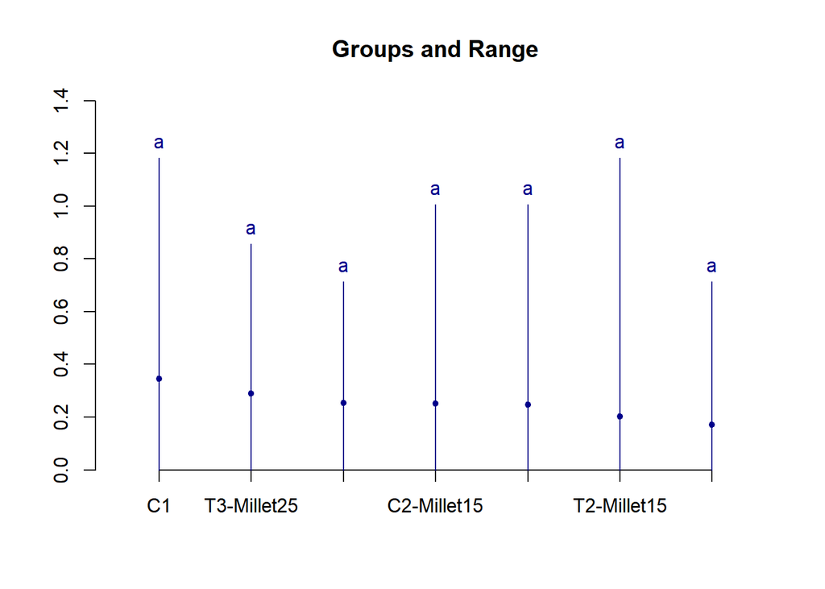

**Figure 5**: Effect of different treatments on Pheritimoid earthworm mortality in Assay 2. Letters indicates Tukeys HSD posthoc comparisons. Same letter indicates non-significant differences.

#Despite transforming the mortality data the article reported graphics of the untransformed data

```
##          group       mean         se
## 1           C1 0.17460317 0.03238887
## 2  C2-Millet15 0.12063492 0.02645695
## 3  C3-Millet25 0.12380952 0.02592347
## 4       T1-B.b 0.12698413 0.02280216
## 5  T2-Millet15 0.10793651 0.03310234
## 6  T3-Millet25 0.14920635 0.02760096
## 7 T4-Alfalfa50 0.07936508 0.01902355
```

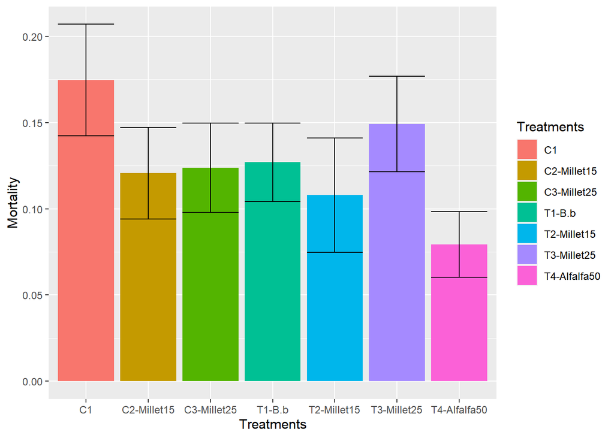

**Figure 6**: Mortality of earthworms in the various treatments(+/-SE)

## **ASSAY 3**

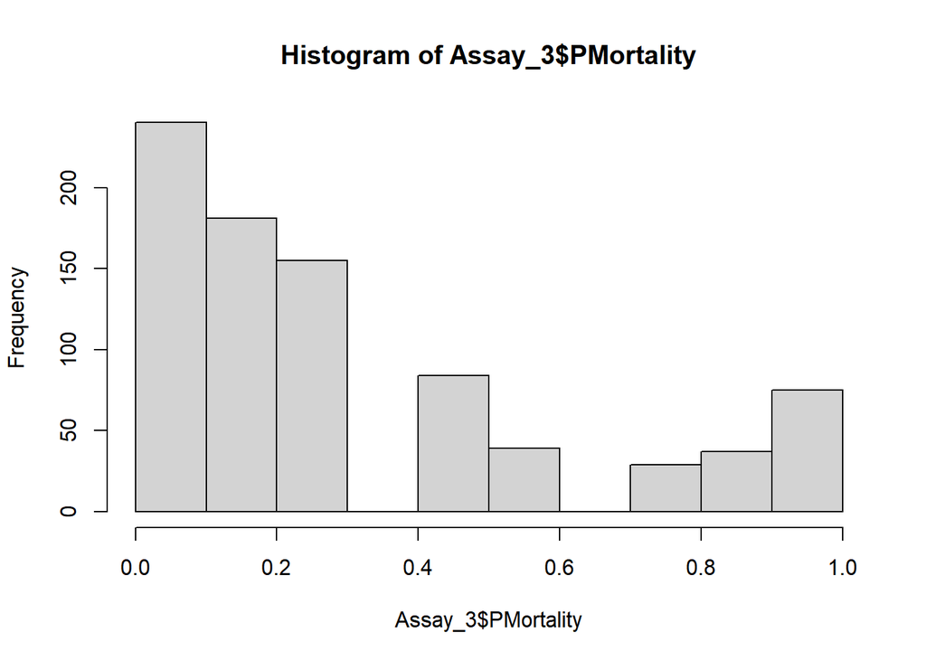

```
##
##  One-sample Kolmogorov-Smirnov test
##
## data:  Assay_3$TMortality
## D = 0.5, p-value < 2.2e-16
## alternative hypothesis: two-sided
```

```
##
##  One-sample Kolmogorov-Smirnov test
##
## data:  Anova.Assay3M$residuals
## D = 0.26036, p-value < 2.2e-16
## alternative hypothesis: two-sided
```

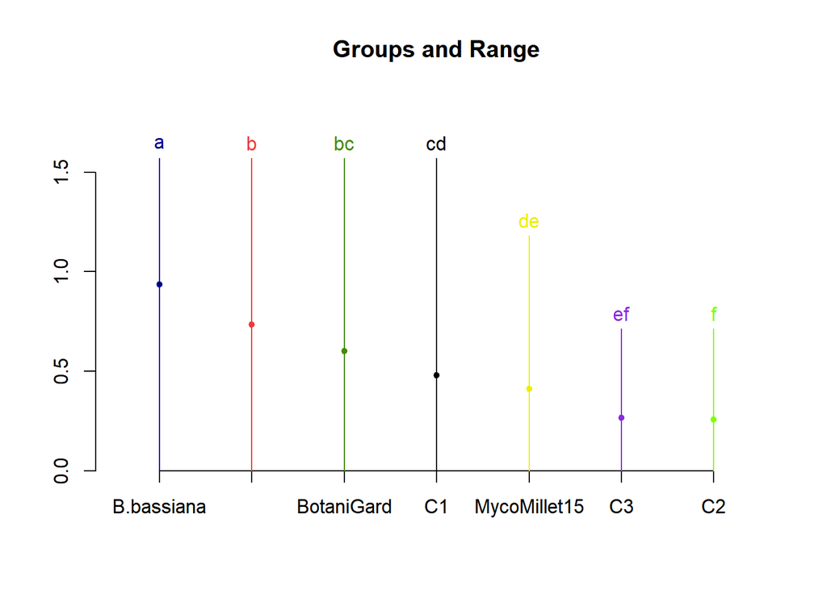

**Figure 8**: Effect of different treatments on Pheritimoid earthworm mortality. Letters indicates Tukeys HSD posthoc comparisons. Same letter indicates non-significant differences.

#Despite transforming the mortality data the article reported graphics of the untransformed data

```
##          group      mean         se
## 1   B.bassiana 0.5952381 0.03365760
## 2   BotaniGard 0.3297619 0.02500762
## 3           C1 0.2904762 0.02961931
## 4           C2 0.1190476 0.01175374
## 5           C3 0.1166667 0.01121236
## 6 MycoMillet15 0.2321429 0.02022161
## 7 MycoMillet25 0.4488095 0.03195706
```

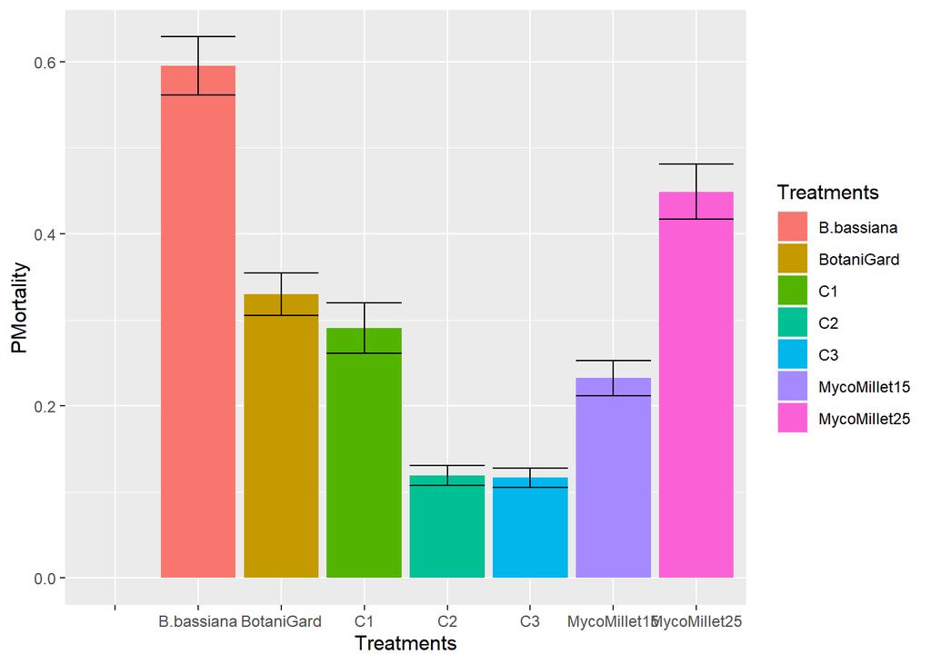

**Figure 9**: Mortality of Earthworms in Various Treatments (+/-)

#### THE MORTALITY DATA IN ALL ASSAYS FAILED TO BECOME NORMALLY DISTRIBUTED AFTER THE TRANSFORMATION

#### HENCE THE MOST APPROPRAITE TEST THAT SHOULD HAVE BEEN USED TO ANALYSE THIS DATA

#### IS A NONE PARAMETRIC TEST LIKE THE KRUSKAL WALLIS TEST

# **STEP 2: KRUSKAL WALLIS ANALYSIS**

## **ASSAY 1**

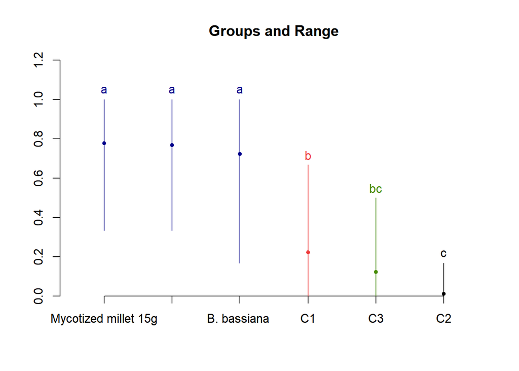

**Figure 10**: Effect of different treatments on the Mortality of Pheritimoid Earthworms in Assay 1

## **ASSAY 2**

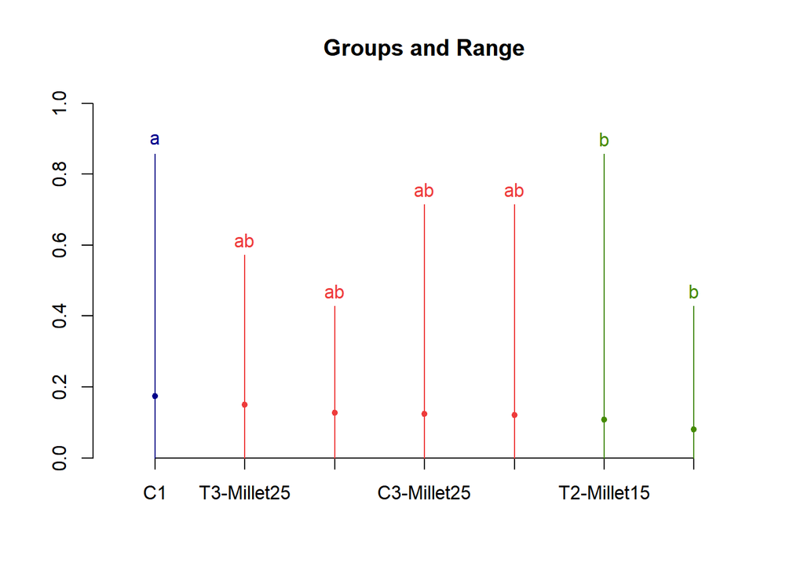

**Figure 11**: Effect of different treatments on the Mortality of Pheritimoid Earthworms in Assay 2

## **ASSAY 3**

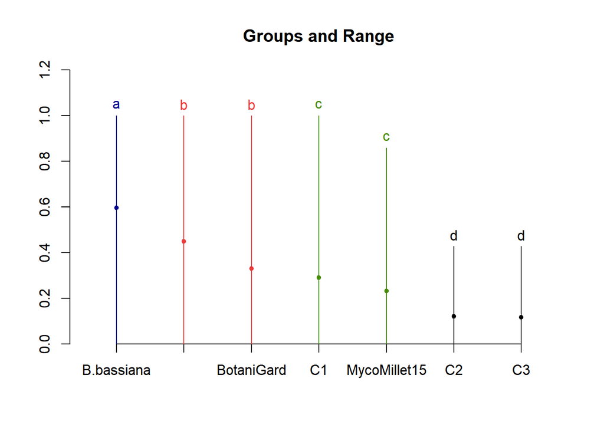

**Figure 12**: Effect of different treatments on the Mortality of Pheritimoid Earthworms in Assay 3

# **STEP 3**